# Dungeness crab bioenergetics: updating model

Kirstin Holsman

# Description

Make the following updates to the original Holsman et al. (2003) model:

1. add ingestion (done)
2. new simulations for molting (done)
3. using the find_ftcpar function in Part 5 of the NRG vignette, re-fit consumption parameters Tco and Qc (in progress)

*units??*

# Data

## consumption experiments

All of the experimental data from 2018 has been cleaned up from the original spreadsheet. The data frame contains three separate trials (and so tank numbers are repeated)

```r
dat <- read_csv(here::here(dge_dir,"data","Experiments2018.csv")) %>% filter(species=="Dungeness")
```

```
## -------------------------------------------------------- Delimiter: "," chr
## (2): species, cw_inside_spines dbl (12): ...1, temp, trial, tank, cw_widest,
## crab_mass_g, i_nytex_clip, f_n...
```

```r
str(dat)
```

```
## spc_tbl_ [57 x 14] (S3: spec_tbl_df/tbl_df/tbl/data.frame)
##  $ ...1                   : num [1:57] 1 2 3 4 5 6 7 8 9 10 ...
##  $ species                : chr [1:57] "Dungeness" "Dungeness" "Dungeness" "Dungeness" ...
##  $ temp                   : num [1:57] 7.5 7.5 7.5 7.5 7.5 7.5 7.5 7.5 10 10 ...
##  $ trial                  : num [1:57] 1 1 1 1 1 1 1 1 3 3 ...
##  $ tank                   : num [1:57] 1 2 3 4 5 6 8 9 12 13 ...
##  $ cw_widest              : num [1:57] 136 124 138 133 124 ...
##  $ cw_inside_spines       : chr [1:57] "129.9" "116.7" "131.4" "126.7" ...
##  $ crab_mass_g            : num [1:57] 353 250 387 318 284 245 320 304 NA NA ...
##  $ i_nytex_clip           : num [1:57] 2.26 2.32 2.07 2.16 2.1 2.14 2.15 2.03 2.1 2.13 ...
##  $ f_nytex_clip           : num [1:57] 1.99 2.3 2.07 2.14 2.24 2.25 2.01 2.05 2.23 2.25 ...
##  $ total_squid_added      : num [1:57] 17.6 14.3 17.1 15.1 13.2 ...
##  $ squid_disc_left        : num [1:57] 12.06 9.49 11.82 9.04 7.36 ...
##  $ i_filtered_w_nytex_clip: num [1:57] 2.36 2.38 2.11 2.83 2.3 2.26 2.21 2.18 2.42 2.51 ...
##  $ f_filtered_w_nytex_clip: num [1:57] 2.12 2.37 2.53 2.21 2.34 2.34 2.23 2.21 NA NA ...
##  - attr(*, "spec")=
##   .. cols(
##   ..   ...1 = col_double(),
##   ..   species = col_character(),
##   ..   temp = col_double(),
##   ..   trial = col_double(),
##   ..   tank = col_double(),
##   ..   cw_widest = col_double(),
##   ..   cw_inside_spines = col_character(),
##   ..   crab_mass_g = col_double(),
##   ..   i_nytex_clip = col_double(),
##   ..   f_nytex_clip = col_double(),
##   ..   total_squid_added = col_double(),
##   ..   squid_disc_left = col_double(),
##   ..   i_filtered_w_nytex_clip = col_double(),
##   ..   f_filtered_w_nytex_clip = col_double()
##   .. )
##  - attr(*, "problems")=<externalptr>
```

For trial 1, Calculate the ingestion loss (I), egestion (F), consumption (C), and specific consumption (in gWW prey / gWW predator).

```r
cdat <- dat %>%
  filter(trial==1) %>%
  mutate(I=i_filtered_w_nytex_clip-i_nytex_clip,
                F=f_filtered_w_nytex_clip-f_nytex_clip,
                C=total_squid_added - (squid_disc_left + I),  ## Note that in experimental data sheet, C calculation doesn't account for I
                C_gg=C/crab_mass_g)
head(dplyr::select(cdat, crab_mass_g, total_squid_added, squid_disc_left, I, F, C, C_gg))
```

| crab_mass_g | total_squid_added | squid_disc_left | I | F | C | C_gg |
| --- | --- | --- | --- | --- | --- | --- |
| 353 | 17.65 | 12.06 | 0.10 | 0.13 | 5.49 | 0.0155524 |
| 250 | 14.31 | 9.49 | 0.06 | 0.07 | 4.76 | 0.0190400 |
| 387 | 17.07 | 11.82 | 0.04 | 0.46 | 5.21 | 0.0134625 |
| 318 | 15.14 | 9.04 | 0.67 | 0.07 | 5.43 | 0.0170755 |
| 284 | 13.23 | 7.36 | 0.20 | 0.10 | 5.67 | 0.0199648 |
| 245 | 15.51 | 10.04 | 0.12 | 0.09 | 5.35 | 0.0218367 |

### option 1: consumption in gPrey/gPred

Fit the new parameters using consumption from the experiments, as g Prey AFDW / g Pred AFDW.

Re-calculate the C_gg value, so that it is in ash-free dry weight (like the model; currently in WW). I can first calculate crab AFDW using the carapace width for Dungeness crab (in Holsman et al. 2003).

```r
cdat_AFDW <- cdat %>%
  mutate(crab_mass_gAFDW=(0.00005068 * (as.numeric(cw_inside_spines)^(2.79))))
```

I don’t have a good conversion factor for squid, but I do have an average % water (of WW) and an average % Ash (of DW) across a range of squid species, from: Nancy Davis 1993. Caloric content of oceanic zooplankton and fishes for studies of salmonid food habits and their ecologically related species. (NPAFC Doe.) FRI-UW-93 12. Fisheries Research Institute, University of Washington, Seattle. 10 pp

Can I use these averages as conversion factors? g squid WW * (ww2dw as average % water) * (dw2afdw as average % ash)

```r
ww2dw <- mean(0.69,0.72,0.817,0.852)
dw2afdw <- mean(0.07,0.08,0.094,0.064,0.092)

cdat_AFDW %<>% mutate(C_gAFDW=(total_squid_added - squid_disc_left)*ww2dw*dw2afdw) %>%
  mutate(C_ggAFDW=C_gAFDW/crab_mass_gAFDW)

head(dplyr::select(cdat_AFDW, temp,crab_mass_g, crab_mass_gAFDW,C, C_gAFDW, C_gg, C_ggAFDW))
```

| temp | crab_mass_g | crab_mass_gAFDW | C | C_gAFDW | C_gg | C_ggAFDW |
| --- | --- | --- | --- | --- | --- | --- |
| 7.5 | 353 | 39.97663 | 5.49 | 0.269997 | 0.0155524 | 0.0067539 |
| 7.5 | 250 | 29.64588 | 4.76 | 0.232806 | 0.0190400 | 0.0078529 |
| 7.5 | 387 | 41.27791 | 5.21 | 0.253575 | 0.0134625 | 0.0061431 |
| 7.5 | 318 | 37.28923 | 5.43 | 0.294630 | 0.0170755 | 0.0079012 |
| 7.5 | 284 | 30.79385 | 5.67 | 0.283521 | 0.0199648 | 0.0092071 |
| 7.5 | 245 | 28.52573 | 5.35 | 0.264201 | 0.0218367 | 0.0092618 |

The value `C_ggAFDW` is what is put into the find_ftcpar function.

### option 2: Percent max consumption

Use the parameters from the model to calculate **theoretical** maximum possible consumption (will be in g AFDW) from crab mass and temperature. Then divide specific consumption by maximum consumption, to get proportion max consumption. Since it’s a proportion, I don’t have to convert units, I think?

Note that this does require using the estimated (not fitted) values for $Tco$ and $QC$, when calculating max consumption.

in the `bioE` function for NRG, maximum specific consumption rate at temperature T = $C_{max}$ = $C_A * W^{C_B} *f(T_c) * E_{prey}$. And $f(T_c)$ is created using the NRG function `fTC_fun`. This gives maximum consumption as J / g pred AFDW / day

First, get the values for $f(T_c)$. This requires the input parameters, and a data frame with the temperatures from the experiment.

```r
inparms <- crabPARMS_USE %>% filter(X=="Cmagister")

tdat <- data.frame(TempC=cdat$temp)
ftc_dat <- fTC_fun(par=inparms,data=tdat)

cdat %<>% bind_cols(ftc=ftc_dat)
```

Then, calculate “W” (g AFDW) from the carapace width, using equation 6 from Holsman et al.

```r
cdat %<>% mutate(crab_mass_gAFDW=(0.00005068 * (as.numeric(cw_inside_spines)^(2.79))))
```

Now we have $f(T_c)$ and $W$, and we already have $C_A$ and $C_B$ in the parameters data frame. Putting that altogether we get $C_{max}$ in g Pred AFDW:

```r
cdat %<>%
  mutate(Cmax=inparms$CA*(crab_mass_gAFDW^inparms$CB)*ftc)
head(dplyr::select(cdat, temp, crab_mass_g, C_gg, ftc,Cmax))
```

| temp | crab_mass_g | C_gg | ftc | Cmax |
| --- | --- | --- | --- | --- |
| 7.5 | 353 | 0.0155524 | 0.6870428 | 1.763865 |
| 7.5 | 250 | 0.0190400 | 0.6870428 | 1.904166 |
| 7.5 | 387 | 0.0134625 | 0.6870428 | 1.749460 |
| 7.5 | 318 | 0.0170755 | 0.6870428 | 1.795570 |
| 7.5 | 284 | 0.0199648 | 0.6870428 | 1.885736 |
| 7.5 | 245 | 0.0218367 | 0.6870428 | 1.923035 |

Convert $C_{max}$ to g Pred WW.

Finally, multiply the proportion of max consumption by the max consumption value in g AFDW.

```r
cdat %<>%
  mutate(Cmax_WW=Cmax*0.123) %>%
  mutate(Cp=C_gg/Cmax_WW) %>%
  mutate(C_ggAFDW=Cp*Cmax)

head(dplyr::select(cdat, temp, crab_mass_g, C,C_gg, ftc,Cmax,Cmax_WW,Cp,C_ggAFDW))
```

| temp | crab_mass_g | C | C_gg | ftc | Cmax | Cmax_WW | Cp | C_ggAFDW |
| --- | --- | --- | --- | --- | --- | --- | --- | --- |
| 7.5 | 353 | 5.49 | 0.0155524 | 0.6870428 | 1.763865 | 0.2169554 | 0.0716848 | 0.1264423 |
| 7.5 | 250 | 4.76 | 0.0190400 | 0.6870428 | 1.904166 | 0.2342125 | 0.0812937 | 0.1547967 |
| 7.5 | 387 | 5.21 | 0.0134625 | 0.6870428 | 1.749460 | 0.2151836 | 0.0625630 | 0.1094515 |
| 7.5 | 318 | 5.43 | 0.0170755 | 0.6870428 | 1.795570 | 0.2208551 | 0.0773153 | 0.1388250 |
| 7.5 | 284 | 5.67 | 0.0199648 | 0.6870428 | 1.885736 | 0.2319456 | 0.0860753 | 0.1623154 |
| 7.5 | 245 | 5.35 | 0.0218367 | 0.6870428 | 1.923035 | 0.2365333 | 0.0923199 | 0.1775344 |

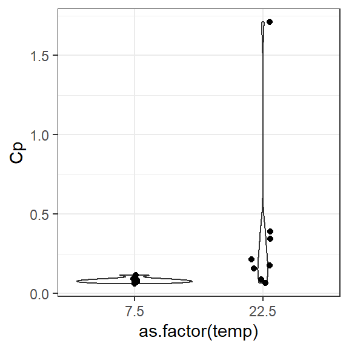

Let’s assume that the top point is an outlier, and remove it from the dataset that will be used to fit new parameters

```r
cdat_fitting <- filter(cdat, Cp < 1)
```

The value `C_ggAFDW` is what is put into the find_ftcpar function.

# Fit consumption

estimate the consumption curves - and re-fit consumption parameters Tco and Qc - using MCMC to draw from informly distributed intial conditions.

### option 1: consumption in gPrey/gPred AFDW

```r
newDat1 <- cdat_AFDW %>%
  mutate(N_fed=115) %>%
  rename(Temp=temp,Size_CW=cw_widest,W_g=crab_mass_gAFDW,C_g=C_gAFDW,C_ggd=C_ggAFDW) %>%
  dplyr::select(Temp,Size_CW,W_g,C_g,C_ggd,I,F)
newDat1
```

| Temp | Size_CW | W_g | C_g | C_ggd | I | F |
| --- | --- | --- | --- | --- | --- | --- |
| 7.5 | 136.0 | 39.97663 | 0.269997 | 0.0067539 | 0.10 | 0.13 |
| 7.5 | 123.7 | 29.64588 | 0.232806 | 0.0078529 | 0.06 | 0.07 |
| 7.5 | 138.4 | 41.27791 | 0.253575 | 0.0061431 | 0.04 | 0.46 |
| 7.5 | 132.7 | 37.28923 | 0.294630 | 0.0079012 | 0.67 | 0.07 |
| 7.5 | 123.6 | 30.79385 | 0.283521 | 0.0092071 | 0.20 | 0.10 |
| 7.5 | 121.2 | 28.52573 | 0.264201 | 0.0092618 | 0.12 | 0.09 |
| 7.5 | 133.7 | 37.86686 | 0.396543 | 0.0104720 | 0.06 | 0.22 |
| 7.5 | 125.7 | 30.72128 | 0.243432 | 0.0079239 | 0.15 | 0.16 |
| 22.5 | 139.9 | 41.19032 | 1.800141 | 0.0437030 | 2.07 | 0.53 |
| 22.5 | 132.7 | 36.63603 | 0.100464 | 0.0027422 | 0.29 | 0.03 |
| 22.5 | 125.2 | 31.67328 | 0.342447 | 0.0108119 | 0.37 | 0.24 |
| 22.5 | 132.8 | 37.37140 | 0.348726 | 0.0093314 | 0.25 | 0.26 |
| 22.5 | 138.9 | 41.54138 | 0.185955 | 0.0044764 | 0.45 | 0.26 |
| 22.5 | 153.4 | 53.70678 | 0.096117 | 0.0017897 | 0.11 | 0.47 |
| 22.5 | 129.7 | 34.72062 | 0.213486 | 0.0061487 | 0.10 | 0.25 |
| 22.5 | 133.8 | 37.28923 | 0.181125 | 0.0048573 | 0.16 | 0.07 |

make sure that the function `find_ftcpar` works with some changes to input names.

```r
inparms <- crabPARMS_USE %>% filter(X=="Cmagister")

indat <- list(
    logitlink    = TRUE,
    fitsigma     = FALSE,
    sigset       = 0.02,
    TempCIN      = newDat1$Temp,
    ftc_obsIN    = newDat1$C_ggd)
```

Is the function working?

```r
find_ftcpar(
  parms_use    = inparms,
  par = c(
    logTco   = log(8),
    logQc    = log(2),
    logsigma = log(.0002)),
  data=indat)
```

```
## [1] -0.1081853
```

```r
m<-optim(fn=find_ftcpar,par=c(logTco=log(8),logQc=log(2),
                              logsigma=log(.0002)),parms_use = inparms,data=indat,
         hessian=TRUE,control=list(maxit=1e6))
# vc <- solve(m$hessian)
# se<-(sqrt(diag(vc)))


round(exp(m$par),3)
```

```
##       logTco        logQc     logsigma
## 4.140439e+18 0.000000e+00 5.300000e-02
```

How close are these to our original values?

```r
inparms$Tco ; inparms$QC
```

```
## [1] 14.5
```

```
## [1] 5
```

yikes…

### option 2: consumption as proportion of maximum consumption

```r
newDat2 <- cdat_fitting %>%
  mutate(N_fed=115) %>%
  rename(Temp=temp,W_g=crab_mass_g,C_g=C_gg,C_ggd=C_ggAFDW) %>%
  dplyr::select(Temp,C_ggd,I,F)
newDat2
```

| Temp | C_ggd | I | F |
| --- | --- | --- | --- |
| 7.5 | 0.1264423 | 0.10 | 0.13 |
| 7.5 | 0.1547967 | 0.06 | 0.07 |
| 7.5 | 0.1094515 | 0.04 | 0.46 |
| 7.5 | 0.1388250 | 0.67 | 0.07 |
| 7.5 | 0.1623154 | 0.20 | 0.10 |
| 7.5 | 0.1775344 | 0.12 | 0.09 |
| 7.5 | 0.2070630 | 0.06 | 0.22 |
| 7.5 | 0.1307766 | 0.15 | 0.16 |
| 22.5 | 0.0451952 | 0.29 | 0.03 |
| 22.5 | 0.2077344 | 0.37 | 0.24 |
| 22.5 | 0.1765317 | 0.25 | 0.26 |
| 22.5 | 0.0776468 | 0.45 | 0.26 |
| 22.5 | 0.0308779 | 0.11 | 0.47 |
| 22.5 | 0.1111454 | 0.10 | 0.25 |
| 22.5 | 0.0900833 | 0.16 | 0.07 |

make sure that the function `find_ftcpar` works with some changes to input names.

```r
inparms <- crabPARMS_USE %>% filter(X=="Cmagister")

indat <- list(
    logitlink    = TRUE,
    fitsigma     = FALSE,
    sigset       = 0.02,
    TempCIN      = newDat2$Temp,
    ftc_obsIN    = newDat2$C_ggd)
```

Is the function working?

```r
find_ftcpar(
  parms_use    = inparms,
  par = c(
    logTco   = log(8),
    logQc    = log(2),
    logsigma = log(.0002)),
  data=indat)
```

```
## [1] -1.7803
```

```r
m2<-optim(fn=find_ftcpar,par=c(logTco=log(8),logQc=log(2),
                              logsigma=log(.0002)),parms_use = inparms,data=indat,
         hessian=TRUE,control=list(maxit=1e6))
# vc <- solve(m$hessian)
# se<-(sqrt(diag(vc)))


round(exp(m2$par),3)
```

```
##   logTco    logQc logsigma
##   58.744   20.305    0.000
```

How close are these to our original values?

```r
inparms$Tco ; inparms$QC
```

```
## [1] 14.5
```

```
## [1] 5
```

argh…

# Test run Holsman model

## temperature

For now, let’s use intertidal temperature (from WSG crab team) from Oysterville in Willapa Bay

```r
load(here(nrg_dir,'data','WillapaBayTemperature.rds'))
str(WillapaBayTemperature)
```

```
## List of 3
##  $ WB.1999            :'data.frame': 5136 obs. of  4 variables:
##   ..$ date     : chr [1:5136] "4/1/99" "4/1/99" "4/1/99" "4/1/99" ...
##   ..$ TempC    : num [1:5136] 9 9 9 8.3 8.1 8.4 8.3 8.2 8.1 7.7 ...
##   ..$ time_step: num [1:5136] 1 2 3 4 5 6 7 8 9 10 ...
##   ..$ hour     : 'hms' num [1:5136] 00:00:00 01:00:00 02:00:00 03:00:00 ...
##   .. ..- attr(*, "units")= chr "secs"
##  $ WB.longbeach.2021  :'data.frame': 4165 obs. of  4 variables:
##   ..$ date     : Date[1:4165], format: "2021-06-09" "2021-06-10" ...
##   ..$ temp_c   : num [1:4165] 14.9 14.1 13.5 13.2 13.1 ...
##   ..$ time_step: chr [1:4165] "1" "2" "3" "4" ...
##   ..$ hour     : int [1:4165] 23 0 1 2 3 4 5 6 7 8 ...
##  $ WB.oysterville.2021:'data.frame': 3307 obs. of  4 variables:
##   ..$ date     : Date[1:3307], format: "2021-06-10" "2021-06-10" ...
##   ..$ TempC    : num [1:3307] 14 13.4 13 12.9 12.8 ...
##   ..$ time_step: chr [1:3307] "1" "2" "3" "4" ...
##   ..$ hour     : int [1:3307] 0 1 2 3 4 5 6 7 8 9 ...
```

Get a daily average temperature

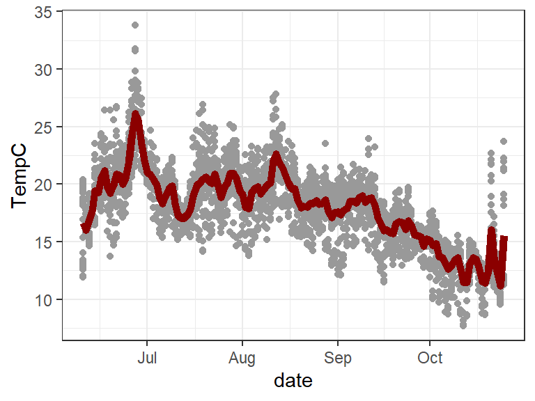

```r
Tdat_raw <- WillapaBayTemperature$WB.oysterville.2021
Tdat <- Tdat_raw %>%
  group_by(date) %>%
  summarise(TempC=mean(TempC))
ggplot() + geom_point(data=Tdat_raw, aes(x=date, y=TempC), col="grey60") +
  geom_path(data=Tdat, aes(x=date,y=TempC, group=1), col="darkred", linewidth=2)
```

## with original parameters

Dungeness crab parameters

```r
parms <- crabPARMS_USE %>% filter(X=="Cmagister"); str(parms)
```

```
## 'data.frame':    1 obs. of  30 variables:
##  $ X    : Factor w/ 3 levels "Cgracilis","Cmaenas",..: 3
##  $ RFR  : int 1
##  $ Qox  : num 13560
##  $ a    : logi NA
##  $ Ceq  : int 3
##  $ Req  : int 0
##  $ Weq  : int 1
##  $ Tco  : num 14.5
##  $ Tcm  : num 20.2
##  $ QC   : int 5
##  $ Tcl  : num 21.2
##  $ CK1  : num 0.42
##  $ CK4  : num 0.83
##  $ CA   : num 6.6
```

[output cut: 16 more lines]

molt information is in its own data frame:

```r
dataMOLT$Cmagister
```

```
## $mod
## [1] 1
##
## $ip
##      a      b
## 1 5.25 0.0175
##
## $mi
##     a    b    c
## 1 1.3 0.23 0.22
##
## $exuviaW
## [1] 0.03
##
## $DD
##   Tmin DDthreshold
## 1    5          NA
```

Set up the simulation with some fake weights

```r
nd     <-  dim(Tdat)[1] # days of simulation
# at start of simulation
Wstart <- 2

## made up simulation day, weights + date
Wobs   <- data.frame(
  day = c(1,nd),
  W   = c(Wstart,16))
Wobs$date <- Tdat$date[Wobs$day]

# simulation data
sim_dat       <- dcrab_data
sim_dat$TempC <- Tdat$TempC     ## temperatures
sim_dat$W     <- Wstart         ## set W data for the simulation to the first observed weight

DCRBdat4sim   <- list(
                  Wtarget  = Wobs,
                  parSIM  = parms,
                  simTdat = Tdat,
                  dataSIM  = sim_dat,
                  dataMOLT = dataMOLT$Cmagister)

sim_out       <- Tdat %>% mutate(W=0)
```

```r
dcrb.oy.sim <- sim_W(par=0.4, dataIN=DCRBdat4sim, LL=F)
```

```
## daily growth includes energy lost to exuvia / spawning (3235.99 J/g predator)
```

```
## carapace width 249.83 calculated from weight; using the equation: 0.000164 * CW^2.79.
```

```
## daily growth includes energy lost to exuvia / spawning (3235.99 J/g predator)
```

```
## carapace width 672.13 calculated from weight; using the equation: 0.000164 * CW^2.79.
```

```
## daily growth includes energy lost to exuvia / spawning (3235.99 J/g predator)
```

```
## carapace width 1399.46 calculated from weight; using the equation: 0.000164 * CW^2.79.
```

```
## daily growth includes energy lost to exuvia / spawning (3235.99 J/g predator)
```

```
## carapace width 1472.48 calculated from weight; using the equation: 0.000164 * CW^2.79.
```

```
## Your crab molted on day: 34, 75, 127, 138,
```

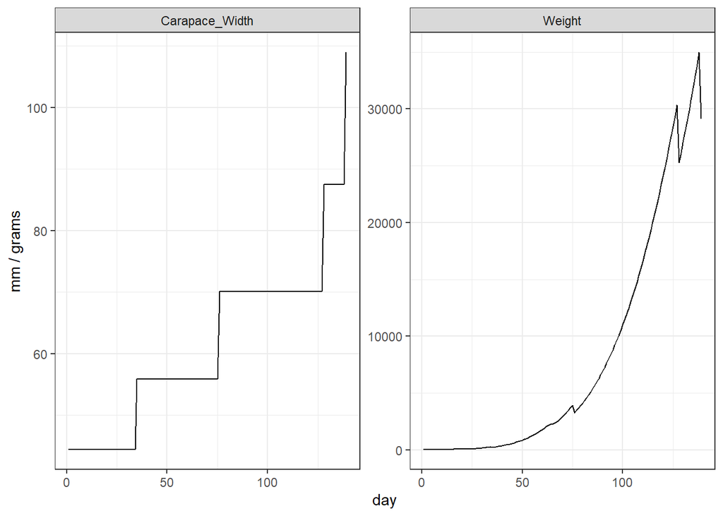

Weight seems high, will need to come back to that.

## with newly fit parameters

Dungeness crab parameters

```r
parms2 <- crabPARMS_USE %>% filter(X=="Cmagister")
parms2$Tco <- exp(m$par["Tco"])
  parms2$QC <- exp(m$par["QC"])
```

molt information is in its own data frame:

```r
dataMOLT$Cmagister
```

Set up the simulation with some fake weights

```r
nd     <-  dim(Tdat)[1] # days of simulation
# at start of simulation
Wstart <- 2

## made up simulation day, weights + date
Wobs   <- data.frame(
  day = c(1,nd),
  W   = c(Wstart,16))
Wobs$date <- Tdat$date[Wobs$day]

# simulation data
sim_dat       <- dcrab_data
sim_dat$TempC <- Tdat$TempC     ## temperatures
sim_dat$W     <- Wstart         ## set W data for the simulation to the first observed weight

DCRBdat4sim   <- list(
                  Wtarget  = Wobs,
                  parSIM  = parms2,
                  simTdat = Tdat,
                  dataSIM  = sim_dat,
                  dataMOLT = dataMOLT$Cmagister)

sim_out       <- Tdat %>% mutate(W=0)
```

```r
dcrb.oy.sim <- sim_W(par=0.4, dataIN=DCRBdat4sim, LL=F)
```

[output not shown]

# parking lot

Let’s just take an average of the values for whole squid reported by: Nancy Davis 1993. Caloric content of oceanic zooplankton and fishes for studies of salmonid food habits and their ecologically related species. (NPAFC Doe.) FRI-UW-93 12. Fisheries Research Institute, University of Washington, Seattle. 10 pp

```r
squid.df <- data.frame(species=c("Illex illacabrosus","Illex illacabrosus","Illex illacabrosus","Loligo paelei","Loligo paelei","Loligo paelei","Loligo bravis","Squids"),
                           sample_area=c("NW atlantic","NW atlantic","NW atlantic","NW atlantic","NW atlantic","NW atlantic","NE Atlantic","Bristol Bay"),
                           calgWW=c(1695,NA,NA,1337,NA,NA,1051,NA),
                           calgAFDW=c(5636,5875,5397,5110,4991,5540,6342,5578)) %>%
  mutate(JgAFDW=calgAFDW*4.184)
squid_ed=mean(squid.df$JgAFDW); squid_ed
```

```
## [1] 23257.29
```